# OmicsON

Monika Piwowar, Wiktor Jurkowski, Ewa Gajda, Cezary Turek

2019-04-14

```r
knitr::opts_chunk$set(echo = FALSE, warning = FALSE, message = FALSE, error = TRUE)
```

# Table of Contents

1. About OmicsON
2. OmicsON workflow
- 1. Set up mapping files
- 2. Data input
- 3. Decorate data by Reactome data
- 4. Decorate data by STRING data
- 5. Functional Ineractions DF
- 7. Multivariate Statistical Analysis
  - 1. CCA - Canonical Correlation Analysis
  - 2. PLS - Partial Least Squares Regression

## About OmicsON

OmicsON provides knowedge driven data regularisation to facilitate multivariate analysis of ‘omics’ data.

## OmicsON Workflow

Below you will find OmicsON workflow described step by step. By following these steps and using examplary data included in this package user should get the same results as shown in this vignette.

### Data input

After setting up mapping, to start work with OmicsON you need to provide two ‘omics’ data sets in data frame form. Data frame can be created from files as in directory under package insallation directory. This files are in tab delimited files with headers (colnames and rownames). Files are named `nm-transcriptomics.txt` and `nm-lipidomics.txt`.

Lipidomisc data

| ChEBI | lin.wt | sun.wt | sun.wt.1 | fish.wt | ref.wt | coc.wt |
| --- | --- | --- | --- | --- | --- | --- |
| CHEBI:28875 | 0.3400 | 0.3800 | 0.3600 | 0.2200 | 0.3700 | 1.7000 |
| CHEBI:73705 | 1.1166 | 0.6362 | 0.4674 | 3.8548 | 0.4866 | 0.5095 |
| CHEBI:17268 | 26.0000 | 2.0000 | 23.7000 | 5.8800 | 24.8000 | 26.0400 |
| CHEBI:15756 | 26.4500 | 24.0400 | 23.7000 | 25.4800 | 24.8000 | 26.0400 |
| CHEBI:28842 | 10.2200 | 9.9300 | 8.9600 | 8.1400 | 9.6300 | 6.5900 |
| CHEBI:35465 | 0.3500 | 0.5500 | 0.5500 | 0.4900 | 0.4600 | 0.6600 |

Transcriptomics data

| symbol | lin.wt | sun.wt | sun.wt.1 | fish.wt | ref.wt | coc.wt |
| --- | --- | --- | --- | --- | --- | --- |
| ACAT1 | -0.42 | -0.44 | -0.48 | -0.45 | -0.42 | -0.43 |
| ACAT2 | -0.65 | -0.68 | -0.74 | -0.69 | -0.71 | -0.69 |
| APOB | -0.84 | -0.91 | -1.10 | -0.65 | -0.54 | -0.80 |
| APOC3 | -0.34 | -0.32 | -0.46 | -0.41 | -0.38 | -0.32 |
| APOE | -1.29 | -1.23 | -1.30 | -1.26 | -1.21 | -1.13 |
| CBS | -1.13 | -1.06 | -1.09 | -1.09 | -0.89 | -0.79 |

### Decorate data by Reactome data

As soon as you set up OmincsON and input data are loaded, you are ready to decorate data by data presented in Reactome database. It is done by searching of ontologically related molecules present in Reactome’s pathways. For further processes in that vignette we are using only few rows from input data. Rows are chosen to present possible border cases in a short time. CHEBI:28875 has representation in Reactome pathways. CHEBI:73705 does not have, but we can find representat of that group by ontology in ChEBI database - CHEBI:46761. CHEBI:35465 is not interesting case, no representation and no representants in ChEBI, so mapping and decoration is empty for that id.

```r
    dataToVignetteEvaluation <- lipidomicsInputData[lipidomicsInputData[,"ChEBI"] %in% c("CHEBI:28875","CHEBI:73705", "CHEBI:35465"),]
    decoratedByReactome <- OmicsON::decorateByReactomeData(chebiMoleculesDf = dataToVignetteEvaluation,
                                chebiIdsColumnName = "ChEBI", organismTaxonomyId = '9606')
```

```r
    decoratedByReactome
```

[output not shown]

What algorithm is behind the ontologies mapping? The first two columns of result table represent mapping of all small molecules to respective parents and children of ChEBI ontology: “root” denotes source IDs; if ID already exists in Reactome ontologyId column has the same value, if not but there is an alternative in the form of child or parent in ChEBI ontology, OmicsON put its id under “ontologyId” column. If we can not find root id and can not find any parent or children for it, OmicsON leave it empty.

Full result’s data frame contains respectively:

- root - ChEBIs ids given by user,
- ontologyId - ChEBI ids used in the calculation, it is taken from ChEBI ontology base on root,
- ensembleIds - List including vector of Ensemble’s Ids,
- uniProtIds - List including vector of UniProt’s Ids,
- reactomeIds - List including vector of pathway’s ids from Reactome DB,
- genesSymbolsFromEnsemble - List including vector of gen’s symbols from Reactome DB base on pathway and Ensemble’s Ids,
- genesSymbolsFromUniProt - List including vector of gen’s symbols from Reactome DB base on pathway and UniProt’s Ids,

### Decorate data by STRING data

```r
    decoratedByStringBaseOnEnsembleIds <- OmicsON::decorateByStringDbData(
        chebiIdsToReactomePathways = decoratedByReactome, listOfEnsembleIdColumnName = 'ensembleIds')
```

```r
    decoratedByStringBaseOnUniProtIds <- OmicsON::decorateByStringDbData(
        chebiIdsToReactomePathways = decoratedByReactome, listOfEnsembleIdColumnName = 'uniProtIds')
```

Data frame returned from this method introduces three new columns. Them are, respectively:

- stringIds - List including vector of all STRING’s ids used in computations.
- stringGenesSymbolsExpand - List including vector of all neighbours find in STRING database.
- stringGenesSymbolsNarrow - List including vector of intersection of all neighbours per id from set of ids used in search.

Full data frame resulted from decoration by String DB.

```r
    decoratedByStringBaseOnUniProtIds
```

```
     root  ontologyId   uniProtIds    stringIds
```

1 CHEBI:28875 CHEBI:28875 Q02083, …. 9606.ENS…. 2 CHEBI:73705 CHEBI:46761 P46059, …. 9606.ENS…. 3 CHEBI:35465  
stringGenesSymbolsExpand stringGenesSymbolsNarrow 1 RALA, CX…. GNA11, P…. 2 SLC7A2, …. SLC7A2, …. 3

Please go to Functional Ineractions DF to know how to convert above decorated structures to easily operative data frames.

If you want to know how to traverse through data in decorated structure? I will present it on example. Moste importan is to understand that many cells include list of vectors! Example will show also what mapping to Ensemble can give different results than mapping to UniProt:

```r
    decoratedByStringBaseOnEnsembleIds[1, "root"]
```

[1] CHEBI:28875 Levels: CHEBI:28875 CHEBI:73705 CHEBI:35465

```r
    decoratedByStringBaseOnEnsembleIds[1, "ensembleIds"][[1]]
```

[1] “ENSG00000138744” “ENSG00000007372” “ENSG00000111664” [4] “ENSG00000114902” “ENSG00000115263” “ENSG00000118363” [7] “ENSG00000126266” “ENSG00000127588” “ENSG00000129128” [10] “ENSG00000134443” “ENSG00000140612” “ENSG00000147262” [13] “ENSG00000148737” “ENSG00000165556” “ENSG00000166562” [16] “ENSG00000168036” “ENSG00000174697” “ENSG00000175426” [19] “ENSG00000186188” “ENSG00000197635” “ENSG00000214415” [22] “ENSG00000006128” “ENSG00000006638” “ENSG00000010671” [25] “ENSG00000036828” “ENSG00000038382” “ENSG00000049247” [28] “ENSG00000056291” “ENSG00000060558” “ENSG00000064547” [31] “ENSG00000069966” “ENSG00000075073” “ENSG00000078369” [34] “ENSG00000078401” “ENSG00000078589” “ENSG00000088256” [37] “ENSG00000090104” “ENSG00000091844” “ENSG00000096395” [40] “ENSG00000100739” “ENSG00000101188” “ENSG00000101200” [43] “ENSG00000101292” “ENSG00000101333” “ENSG00000101405” [46] “ENSG00000101850” “ENSG00000102239” “ENSG00000102468” [49] “ENSG00000102539” “ENSG00000105647” “ENSG00000109163” [52] “ENSG00000109255” “ENSG00000110148” “ENSG00000113889” [55] “ENSG00000114450” “ENSG00000115353” “ENSG00000116014” [58] “ENSG00000116741” “ENSG00000117152” “ENSG00000117461” [61] “ENSG00000119714” “ENSG00000120907” “ENSG00000121446” [64] “ENSG00000121764” “ENSG00000121853” “ENSG00000121879” [67] “ENSG00000122375” “ENSG00000122420” “ENSG00000124205” [70] “ENSG00000125787” “ENSG00000126010” “ENSG00000126262” [73] “ENSG00000127074” “ENSG00000127129” “ENSG00000127533” [76] “ENSG00000127920” “ENSG00000127928” “ENSG00000128285” [79] “ENSG00000132911” “ENSG00000133019” “ENSG00000133636” [82] “ENSG00000135046” “ENSG00000135577” “ENSG00000135744” [85] “ENSG00000135914” “ENSG00000136160” “ENSG00000137252” [88] “ENSG00000137841” “ENSG00000138835” “ENSG00000139574” [91] “ENSG00000139679” “ENSG00000140030” “ENSG00000142192” [94] “ENSG00000143125” “ENSG00000143184” “ENSG00000143185” [97] “ENSG00000143248” “ENSG00000143333” “ENSG00000144230” [100] “ENSG00000144891” “ENSG00000145675” “ENSG00000147145” [103] “ENSG00000147246” “ENSG00000147437” “ENSG00000148734” [106] “ENSG00000149782” “ENSG00000150681” “ENSG00000151617” [109] “ENSG00000152034” “ENSG00000152207” “ENSG00000152822” [112] “ENSG00000156049” “ENSG00000156052” “ENSG00000157017” [115] “ENSG00000160145” “ENSG00000160951” “ENSG00000161610” [118] “ENSG00000162188” “ENSG00000163394” “ENSG00000163421” [121] “ENSG00000164220” “ENSG00000164251” “ENSG00000166148” [124] “ENSG00000166863” “ENSG00000167083” “ENSG00000167414” [127] “ENSG00000168243” “ENSG00000168398” “ENSG00000168539” [130] “ENSG00000168959” “ENSG00000169006” “ENSG00000169403” [133] “ENSG00000169618” “ENSG00000169836” “ENSG00000169860” [136] “ENSG00000170214” “ENSG00000170498” “ENSG00000170893” [139] “ENSG00000171049” “ENSG00000171517” “ENSG00000171596” [142] “ENSG00000171631” “ENSG00000171700” “ENSG00000171873” [145] “ENSG00000172354” “ENSG00000172380” “ENSG00000173020” [148] “ENSG00000173198” “ENSG00000173432” “ENSG00000173578” [151] “ENSG00000173612” “ENSG00000174021” “ENSG00000174417” [154] “ENSG00000175591” “ENSG00000176533” “ENSG00000177464” [157] “ENSG00000180210” “ENSG00000180914” “ENSG00000181104” [160] “ENSG00000181408” “ENSG00000182621” “ENSG00000183395” [163] “ENSG00000183484” “ENSG00000183840” “ENSG00000184502” [166] “ENSG00000184574” “ENSG00000184984” “ENSG00000185897” [169] “ENSG00000186469” “ENSG00000186867” “ENSG00000187094” [172] “ENSG00000187258” “ENSG00000188710” “ENSG00000188958” [175] “ENSG00000196639” “ENSG00000197696” “ENSG00000198049” [178] “ENSG00000198121” “ENSG00000198873” “ENSG00000204640” [181] “ENSG00000213903” “ENSG00000213906” “ENSG00000214285” [184] “ENSG00000215644” “ENSG00000240771” “ENSG00000242616” [187] “ENSG00000244165” “ENSG00000253148” “ENSG00000274736” [190] “ENSG00000120436” “ENSG00000167114” “ENSG00000113396” [193] “ENSG00000130304” “ENSG00000148386” “ENSG00000160349” [196] “ENSG00000177984” “ENSG00000184925” “ENSG00000189058”

```r
    decoratedByStringBaseOnEnsembleIds[1, "stringGenesSymbolsNarrow"][[1]]
```

[1] “RALA” “ACOT8” “HTRA2” “NPL” “PTN” “CTSE” “SOAT1” “YARS” “GCG”

```r
    decoratedByStringBaseOnUniProtIds[1, "root"]
```

[1] CHEBI:28875 Levels: CHEBI:28875 CHEBI:73705 CHEBI:35465

```r
    decoratedByStringBaseOnUniProtIds[1, "uniProtIds"][[1]]
```

[1] “Q02083” “A8MTJ3” “O14842” “P01275” “P07492” “P16520”  
[7] “P26367” “P27487” “P29120” “P35222” “P41159” “P61009”  
[13] “P67812” “Q15005” “Q5NUL3” “Q8TDV5” “Q99626” “Q9BY50”  
[19] “Q9NQB0” “Q9P2W3” “Q9Y6A9” “A5PLK6” “O00254” “O00398”  
[25] “O00459” “O14610” “O14775” “O14843” “O14921” “O15130”  
[31] “O15492” “O15539” “O15552” “O43193” “O43194” “O43555”  
[37] “O43612” “O43613” “O43614” “O60229” “O60262” “O75962”  
[43] “O95399” “O95665” “O95837” “P00734” “P01019” “P01042”  
[49] “P01148” “P01178” “P01185” “P01350” “P04083” “P05067”  
[55] “P05305” “P06307” “P08912” “P08949” “P0C0P6” “P0DJI8”  
[61] “P11229” “P12872” “P14138” “P20309” “P20366” “P20382”  
[67] “P20396” “P20800” “P21452” “P21731” “P24530” “P25090”  
[73] “P25098” “P25100” “P25101” “P25103” “P25105” “P25116”  
[79] “P27986” “P28223” “P28335” “P28336” “P29371” “P29992”  
[85] “P30411” “P30550” “P30556” “P30559” “P30679” “P30968”  
[91] “P30989” “P30990” “P32238” “P32239” “P32247” “P34947”  
[97] “P34981” “P34995” “P35348” “P35367” “P35368” “P37288”  
[103] “P41180” “P41220” “P41231” “P41594” “P41595” “P42336”  
[109] “P43088” “P43657” “P46093” “P46094” “P46663” “P47871”  
[115] “P47900” “P47901” “P47992” “P48645” “P49795” “P49796”  
[121] “P49798” “P50148” “P50150” “P50151” “P51810” “P55085”  
[127] “P55773-2” “P58294” “P59768” “P61952” “P62873” “P62879”  
[133] “P63211” “P63215” “P63218” “P83859” “Q00722” “Q01970”  
[139] “Q06187” “Q08116” “Q13255” “Q13304” “Q15077” “Q15147”  
[145] “Q15722” “Q15726” “Q15743” “Q2M5E4” “Q5H8A3” “Q5T6X5”  
[151] “Q6W5P4” “Q765I0” “Q86VW2” “Q8IVG9” “Q8IYL9” “Q8NFJ6”  
[157] “Q8TCW9” “Q92569” “Q92633” “Q92847” “Q969F8” “Q969V1”  
[163] “Q96G91” “Q96P65” “Q96P88” “Q96RI0” “Q99677” “Q99705”  
[169] “Q9GZQ4” “Q9GZQ6” “Q9H1C0” “Q9HAV0” “Q9HB89” “Q9HBW0”  
[175] “Q9HC23” “Q9NPC1” “Q9NQ66” “Q9NS28” “Q9NS75” “Q9UBD3”  
[181] “Q9UBI6” “Q9UBU3-1” “Q9UBY5” “Q9UGC6” “Q9UHF0” “Q9UHM6”  
[187] “Q9UK08” “Q9UKP6” “Q9UNW8” “Q9Y271” “Q9Y5X5” “O00270”  
[193] “Q6P1M0” “P05090” “P31025” “Q6JVE5” “Q6PCB7” “Q6UWW0”  
[199] “Q8WX39” “Q9Y2P4”

```r
    decoratedByStringBaseOnUniProtIds[1, "stringGenesSymbolsNarrow"][[1]]
```

[1] “GNA11” “P2RY10” “BDKRB1” “PROKR2” “OXT” “MLNR”  
[7] “GNRHR” “KISS1R” “RGS2” “KALRN” “GHSR” “GNRH2”  
[13] “FFAR2” “FFAR1” “F2RL3” “MCHR1” “NMUR2” “CHRM3”  
[19] “NTS” “GRP” “ANXA1” “NMBR” “HTR2B” “PLCB2”  
[25] “GNA15” “PIK3CA” “NMU” “KNG1” “NPFF” “GPR65”  
[31] “PROK1” “GPR17” “AGTR1” “GNRH1” “NPFFR1” “PLCB3”  
[37] “MCHR2” “CYSLTR2” “GRM1” “APP” “GNAQ” “SST”  
[43] “PTGER1” “HCRT” “CCKAR” “PROK2” “F2RL2” “F2RL1”  
[49] “AVPR1A” “TAC3” “PTAFR” “TACR3” “TRH” “TACR1”  
[55] “NTSR2” “PROKR1” “P2RY1” “NMUR1” “GRM5” “CHRM1”  
[61] “CXCL8” “ADRA1B” “LTB4R” “NPFFR2” “GPRC6A” “P2RY6”  
[67] “TRHR” “P2RY2” “XCR1” “GRK2” “EDNRA” “GPR4”  
[73] “TAC1” “F2R” “UTS2R” “OXTR” “LPAR5” “FFAR3”  
[79] “GPR132” “PMCH” “RGS19” “GNG2” “CCKBR” “ARHGEF25” [85] “CCK” “EDN3” “PLCB1” “TRIO” “FPR2” “UTS2B”  
[91] “LPAR6” “QRFP” “SAA1” “LPAR1” “NPSR1” “AGT”  
[97] “KISS1” “RGS18” “XCL1” “XCL2” “CNR1” “NTSR1”  
[103] “LPAR3” “PTGFR” “HCRTR2” “OPN4” “EDN2” “CYSLTR1” [109] “TACR2” “HCRTR1” “GNA14” “NMS” “EDNRB” “HTR2A”  
[115] “EDN1” “ADRA1D” “GRPR” “AVP” “ADRA1A” “CHRM5”  
[121] “GRK5” “QRFPR” “NMB” “HRH1” “NPS” “GCGR”  
[127] “LPAR2” “GCG” “MLN” “TBXA2R” “CASR” “LTB4R2”  
[133] “GPR68”

### Functional Ineractions DF

You can create a functional interactions data frame by using this method:

```r
    ontology2EnsembleFunctionalInteractions <- OmicsON::createFunctionalInteractionsDataFrame(decoratedByReactome,
                                                                             singleIdColumnName = 'ontologyId',
                                                                             idsListColumnName = 'ensembleIds')
    ontology2UniProtFunctionalInteractions <- OmicsON::createFunctionalInteractionsDataFrame(decoratedByReactome,
                                                                             singleIdColumnName = 'ontologyId',
                                                                             idsListColumnName = 'uniProtIds')
    ontology2GenesSymboleFromEnsembleFunctionalInteractions <- OmicsON::createFunctionalInteractionsDataFrame(decoratedByReactome,
                                                                             singleIdColumnName = 'ontologyId',
                                                                             idsListColumnName = 'genesSymbolsFromEnsemble')
    ontology2GenesSymboleFromUniProtFunctionalInteractions <- OmicsON::createFunctionalInteractionsDataFrame(decoratedByReactome,
                                                                             singleIdColumnName = 'ontologyId',
                                                                             idsListColumnName = 'genesSymbolsFromUniProt')
    ontology2GenesSymboleFromStringExpandFunctionalInteractions <- OmicsON::createFunctionalInteractionsDataFrame(decoratedByStringBaseOnUniProtIds,
                                                   singleIdColumnName = 'ontologyId',
                                                   idsListColumnName = 'stringGenesSymbolsExpand')
    ontology2GenesSymboleFromStringNarrowFunctionalInteractions <- OmicsON::createFunctionalInteractionsDataFrame(decoratedByStringBaseOnUniProtIds,
                                                   singleIdColumnName = 'ontologyId',
                                                   idsListColumnName = 'stringGenesSymbolsNarrow')
```

| root | ontologyId | ensembleIds | Annotation | Direction | Score |
| --- | --- | --- | --- | --- | --- |
| CHEBI:28875 | CHEBI:28875 | ENSG00000138744 | - | - | 1 |
| CHEBI:28875 | CHEBI:28875 | ENSG00000007372 | - | - | 1 |
| CHEBI:28875 | CHEBI:28875 | ENSG00000111664 | - | - | 1 |
| CHEBI:28875 | CHEBI:28875 | ENSG00000114902 | - | - | 1 |
| CHEBI:28875 | CHEBI:28875 | ENSG00000115263 | - | - | 1 |
| CHEBI:28875 | CHEBI:28875 | ENSG00000118363 | - | - | 1 |

| root | ontologyId | uniProtIds | Annotation | Direction | Score |
| --- | --- | --- | --- | --- | --- |
| CHEBI:28875 | CHEBI:28875 | Q02083 | - | - | 1 |
| CHEBI:28875 | CHEBI:28875 | A8MTJ3 | - | - | 1 |
| CHEBI:28875 | CHEBI:28875 | O14842 | - | - | 1 |
| CHEBI:28875 | CHEBI:28875 | P01275 | - | - | 1 |
| CHEBI:28875 | CHEBI:28875 | P07492 | - | - | 1 |
| CHEBI:28875 | CHEBI:28875 | P16520 | - | - | 1 |

| root | ontologyId | genesSymbolsFromEnsemble | Annotation | Direction | Score |
| --- | --- | --- | --- | --- | --- |
| CHEBI:28875 | CHEBI:28875 | NAAA | - | - | 1 |
| CHEBI:28875 | CHEBI:28875 | PAX6 | - | - | 1 |
| CHEBI:28875 | CHEBI:28875 | GNB3 | - | - | 1 |
| CHEBI:28875 | CHEBI:28875 | SPCS1 | - | - | 1 |
| CHEBI:28875 | CHEBI:28875 | GCG | - | - | 1 |
| CHEBI:28875 | CHEBI:28875 | SPCS2 | - | - | 1 |

| root | ontologyId | genesSymbolsFromUniProt | Annotation | Direction | Score |
| --- | --- | --- | --- | --- | --- |
| CHEBI:28875 | CHEBI:28875 | NAAA | - | - | 1 |
| CHEBI:28875 | CHEBI:28875 | GNAT3 | - | - | 1 |
| CHEBI:28875 | CHEBI:28875 | FFAR1 | - | - | 1 |
| CHEBI:28875 | CHEBI:28875 | GCG | - | - | 1 |
| CHEBI:28875 | CHEBI:28875 | GRP | - | - | 1 |
| CHEBI:28875 | CHEBI:28875 | GNB3 | - | - | 1 |

| root | ontologyId | stringGenesSymbolsExpand | Annotation | Direction | Score |
| --- | --- | --- | --- | --- | --- |
| CHEBI:28875 | CHEBI:28875 | RALA | - | - | 1 |
| CHEBI:28875 | CHEBI:28875 | CX3CL1 | - | - | 1 |
| CHEBI:28875 | CHEBI:28875 | OTC | - | - | 1 |
| CHEBI:28875 | CHEBI:28875 | RCN1 | - | - | 1 |
| CHEBI:28875 | CHEBI:28875 | GNA11 | - | - | 1 |
| CHEBI:28875 | CHEBI:28875 | NOX3 | - | - | 1 |

| root | ontologyId | stringGenesSymbolsNarrow | Annotation | Direction | Score |
| --- | --- | --- | --- | --- | --- |
| CHEBI:28875 | CHEBI:28875 | GNA11 | - | - | 1 |
| CHEBI:28875 | CHEBI:28875 | P2RY10 | - | - | 1 |
| CHEBI:28875 | CHEBI:28875 | BDKRB1 | - | - | 1 |
| CHEBI:28875 | CHEBI:28875 | PROKR2 | - | - | 1 |
| CHEBI:28875 | CHEBI:28875 | OXT | - | - | 1 |
| CHEBI:28875 | CHEBI:28875 | MLNR | - | - | 1 |

### Statistical Analysis

OmicsON provides two statistical methods to analyse those data:

- CCA - Canonical Correlation Analysis
- PLS - Partial Least Squares Regression

#### CCA - Canonical Correlation Analysis

Calculate CCA on data decorated by String DB:

```r
ccaResultsNarrow.73705 <- OmicsON::makeCanonicalCorrelationAnalysis(
        xNamesVector = ontology2GenesSymboleFromStringNarrowFunctionalInteractions$stringGenesSymbolsNarrow,
        yNamesVector = c("CHEBI:73705"),
        XDataFrame = transcriptomicsInputData,
        YDataFrame = lipidomicsInputData)

ccaResultsNarrow.73705.28875 <- OmicsON::makeCanonicalCorrelationAnalysis(
        xNamesVector = ontology2GenesSymboleFromStringNarrowFunctionalInteractions$stringGenesSymbolsNarrow,
        yNamesVector = c("CHEBI:73705", "CHEBI:28875"),
        XDataFrame = transcriptomicsInputData,
        YDataFrame = lipidomicsInputData)
```

If you fall into “singular matrix” problem presented bellow;

```r
ccaResultsExpand.73705 <- OmicsON::makeCanonicalCorrelationAnalysis(
    xNamesVector = ontology2GenesSymboleFromStringExpandFunctionalInteractions$stringGenesSymbolsExpand,
    yNamesVector =  c("CHEBI:73705"),
    XDataFrame = transcriptomicsInputData,
    YDataFrame = lipidomicsInputData)
```

```
## Error in qr.solve(cxx, cxy): singular matrix 'a' in solve
```

Think about xCutoff, yCutoff options. You can use it to remove highly correlated variables. Below the xCutoff is set to 0.7 and it makes the problem solvable.

```r
ccaResultsExpand.73705 <- OmicsON::makeCanonicalCorrelationAnalysis(
    xNamesVector = ontology2GenesSymboleFromStringExpandFunctionalInteractions$stringGenesSymbolsExpand,
    yNamesVector =  c("CHEBI:73705"),
    XDataFrame = transcriptomicsInputData,
    YDataFrame = lipidomicsInputData,
    xCutoff = 0.7)
```

Ploting CCA results:

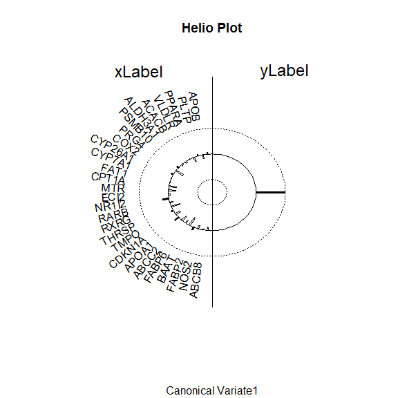

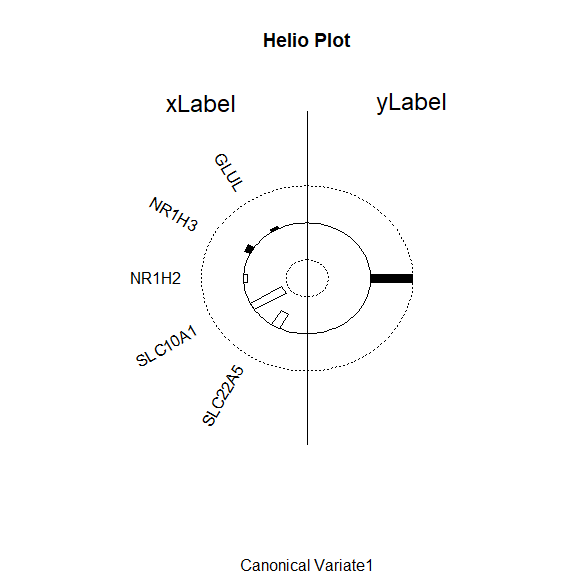

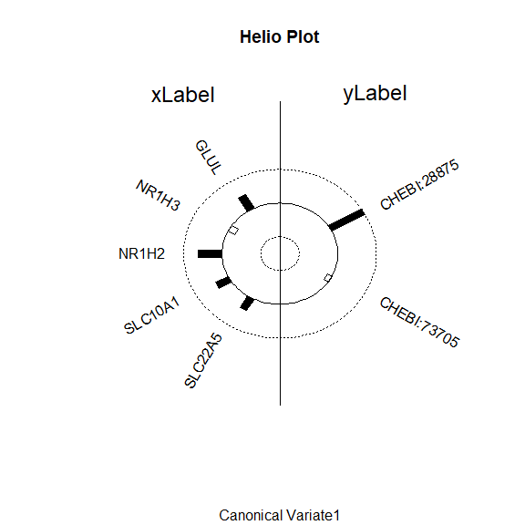

```r
    OmicsON::plotCanonicalCorrelationAnalysisResults(ccaResults = ccaResultsExpand.73705)
    OmicsON::plotCanonicalCorrelationAnalysisResults(ccaResults = ccaResultsNarrow.73705)
    OmicsON::plotCanonicalCorrelationAnalysisResults(ccaResults = ccaResultsNarrow.73705.28875)
```

#### PLS - Partial Least Squares Regression

Calculate PLS on data decorated by String DB:

```r
    PLSResults <- OmicsON::makePartialLeastSquaresRegression(
        xNamesVector = ontology2GenesSymboleFromStringNarrowFunctionalInteractions$stringGenesSymbolsNarrow,
        yNamesVector = c("CHEBI:73705","CHEBI:28875"),
        XDataFrame = transcriptomicsInputData,
        YDataFrame = lipidomicsInputData)
```

How to plot results?

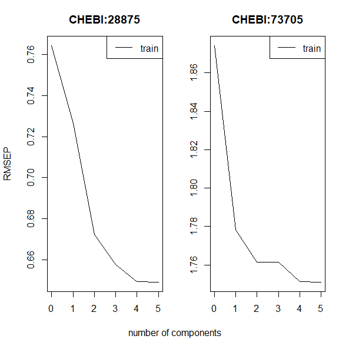

[figure not shown]

```r
    OmicsON::plotRmsepForPLS(PLSResults)
```